# PROJECT 4

## C.2 pH

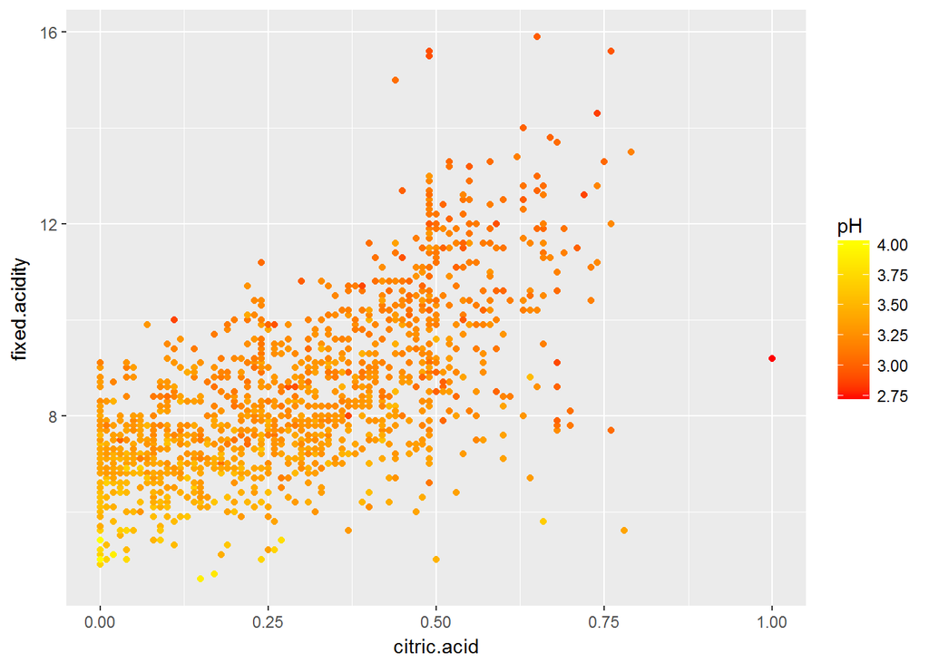

Our earlier observation in bivariate plot also holds true in multivariate, fixed acidity vs citric acid shows a clear trend of increase in pH value when we decrease both of them.

## C.3 Density

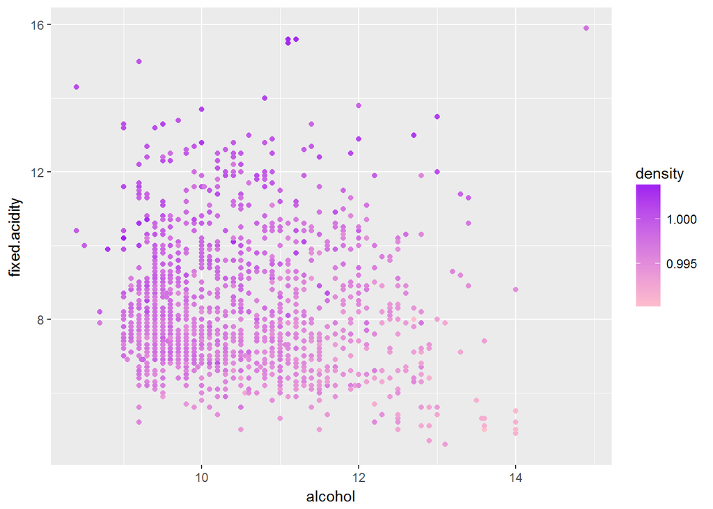

Our earlier observation in bivariate plot also holds true in multivariate, we can see Density decreases with increase in alcohol and increases with increase in fixed acidity clearly.

# Multivariate Analysis

### Were there any interesting or surprising interactions between features?

1.No relation of density with quality is noticed in multivariate analysis, while bivariate analysis showed a relation.

# D. Final Plots and Summary

### Plot One: Quality

[figure not shown]

### Plot Two: Density

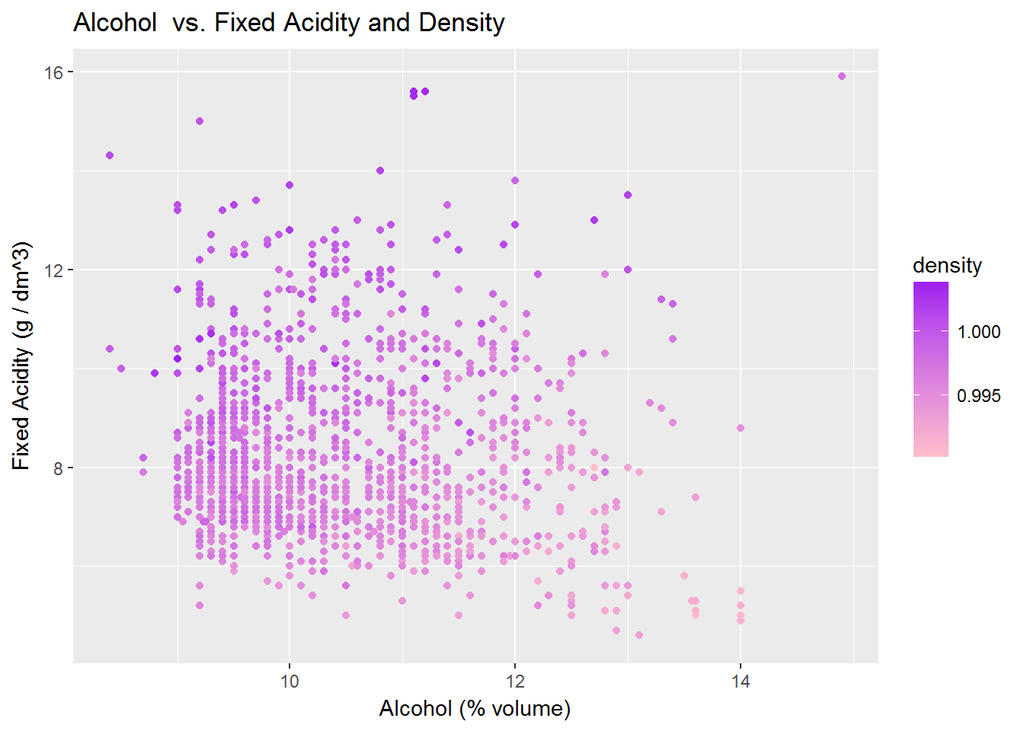

### Description Two

Plot 2 shows how density increases with increase in fixed acidity and decreases with increase in alcohol content. We believe both of them to be significant factor in determining density of the wine.

### Plot Three: pH

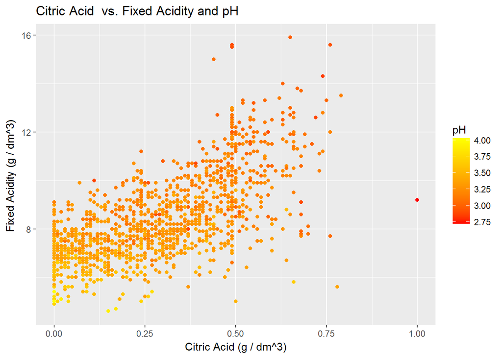

# Reflection

We explored many relationship from our data, few are signficant, few are not, and few needs deeper future exploration.

Significant Insights:

1. Quality being the most important varible, We found the relationship of quality with alcohol, sulphate and volatile acidity significant.
2. We also found how pH value is dependent on the content of citric acid and fxed acidity.
3. Relationship of fixed sulfur dioxide and total sulfur dioxide is very clear.
4. Density’s relation with alcohol and fixed acidity is also very significant.

Future Exploration:

1. Citric acid shows some relation with quality in both bivariate and multivariate analysis, but the relation is not very clear and needs more future exploration.
2. Density’s relation with quality reflects in unvariate not in multivariate. This can also be explored in future.
3. Total sufur dioxide shows a correlation with quality in corrplot but not in bivariate analysis.

Struggles:

1. To make new varaible from quality was a bit difficult and needed some research from google.
2. To draw conclusion from multivariate plots also needed some re-study from videos.